# Milestone Report

DavidVan

10/20/2020

# Exploratory data analyses

## Load necessary libraries

```r
library(knitr)
library(tidyr)
library(rJava)
library(RWeka)
library(dplyr)
library(doParallel)
library(stringi)
library(tm)
library(ggplot2)
library(textclean)
```

## Download and load Capstone dataset

```r
temp <- tempfile()
ArchivoZip <- "https://d396qusza40orc.cloudfront.net/dsscapstone/dataset/Coursera-SwiftKey.zip"
download.file(ArchivoZip, temp)
final <- unzip(temp)
```

Download and load Bad Words file

```r
badWords <- VectorSource(readLines(file("https://raw.githubusercontent.com/RobertJGabriel/Google-profanity-words/master/list.txt", "r")))
```

## Load Data

Read Blogs, News and Twitter data

```r
blogs <- readLines("final//en_US//en_US.blogs.txt", encoding = "UTF-8", skipNul = TRUE)
news <- readLines("final//en_US//en_US.news.txt", encoding = "UTF-8", skipNul = TRUE)
tweets <- readLines("final//en_US//en_US.twitter.txt", encoding = "UTF-8", skipNul = TRUE)
```

Get file sizes in Mb

```r
bl_sz <- file.info("final//en_US//en_US.blogs.txt")$size / 1024 ^ 2
nw_sz <- file.info("final//en_US//en_US.news.txt")$size / 1024 ^ 2
tw_sz <- file.info("final//en_US//en_US.twitter.txt")$size / 1024 ^ 2
```

Compute words per line for each data type

```r
word_line <- lapply(list(blogs, news, tweets), function(x) stri_count_words(x))
```

## Compute statistics and summary for each data type

```r
sum_data <- data.frame(
        File = c("Blogs", "News", "Tweets"),
        Size = c(bl_sz, nw_sz, tw_sz),
        t(rbind(sapply(list(blogs, news, tweets),stri_stats_general),
                Total_Words = sapply(list(blogs, news, tweets),
                                     stri_stats_latex)[4,])),
        wd_line_summary = rbind(summary(word_line[[1]]),
        summary(word_line[[2]]),summary(word_line[[3]]))
)
head(sum_data)
```

```
##     File     Size   Lines LinesNEmpty     Chars CharsNWhite Total_Words
## 1  Blogs 200.4242  899288      899288 206824382   170389539    37570839
## 2   News 196.2775   77259       77259  15639408    13072698     2651432
## 3 Tweets 159.3641 2360148     2360148 162096241   134082806    30451170
##   wd_line_summary.Min. wd_line_summary.1st.Qu. wd_line_summary.Median
## 1                    0                       9                     28
## 2                    1                      19                     32
## 3                    1                       7                     12
##   wd_line_summary.Mean wd_line_summary.3rd.Qu. wd_line_summary.Max.
## 1             41.75107                      60                 6726
## 2             34.61779                      46                 1123
## 3             12.75065                      18                   47
```

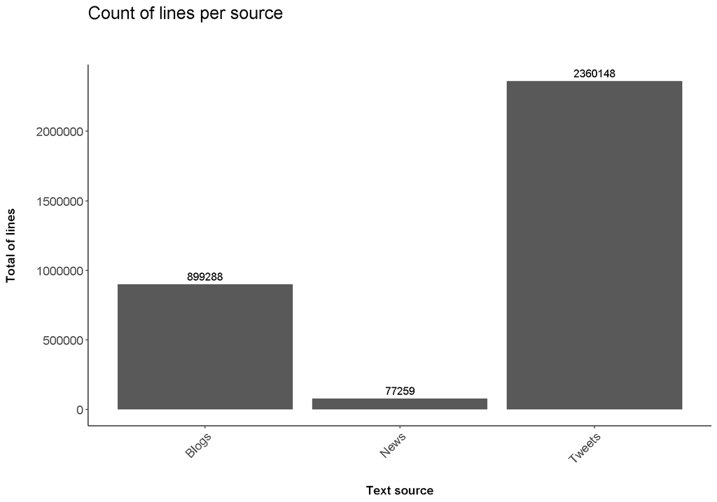

Fig. 1. Count of lines per source Appendix 1.

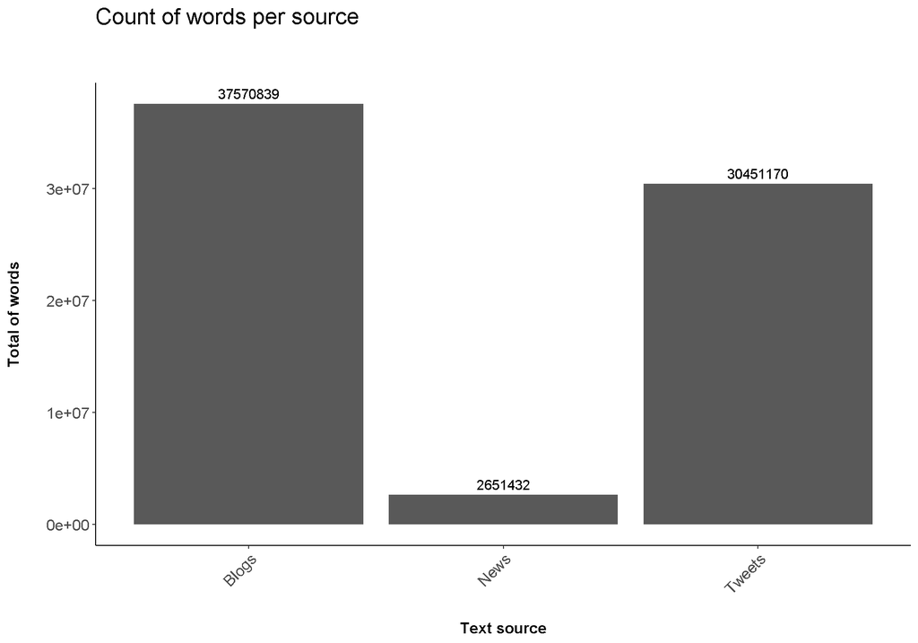

Fig. 2. Count of words per source Appendix 2.

# Sampling and Cleaning Data

Sample data, create corpus and clean data. In this step, remove bad words, punctuation, numbers and extra white spaces; likewise, transform uppercase characters to lowercase characters.

```r
set.seed(1987)
data.sample <- c(sample(blogs, length(blogs) * 0.01),
                 sample(news, length(news) * 0.01),
                 sample(tweets, length(tweets) * 0.01))

corpus <- VCorpus(VectorSource(data.sample))
corpus <- tm_map(corpus, content_transformer(tolower))
corpus <- tm_map(corpus, stripWhitespace)
corpus <- tm_map(corpus, removeNumbers)
corpus <- tm_map(corpus, removePunctuation)
corpus <- tm_map(corpus, removeWords, badWords)
# Corpus without English stop words
corpus2 <- tm_map(corpus, removeWords, stopwords("english"))
```

Find each n-grams in the data using a function

```r
corpusDf <- data.frame(text = unlist(sapply(corpus,
                `[`, "content")), stringsAsFactors = F)

corpusDf2 <- data.frame(text = unlist(sapply(corpus2,
                `[`, "content")), stringsAsFactors = F)

findNGrams <- function(corp, grams) {
        ngram <- NGramTokenizer(corp, Weka_control(min = grams, max = grams))
        ngram2 <- data.frame(table(ngram))
        ngram3 <- ngram2[order(ngram2$Freq, decreasing = TRUE),]
        ngram3
}
```

Further exploratory analysis is done to plot frequency of the most occurring words in unigrams, bigrams and trigrams

# Built n-grams with English stop words and save data in a .RDS file

## Unigram data

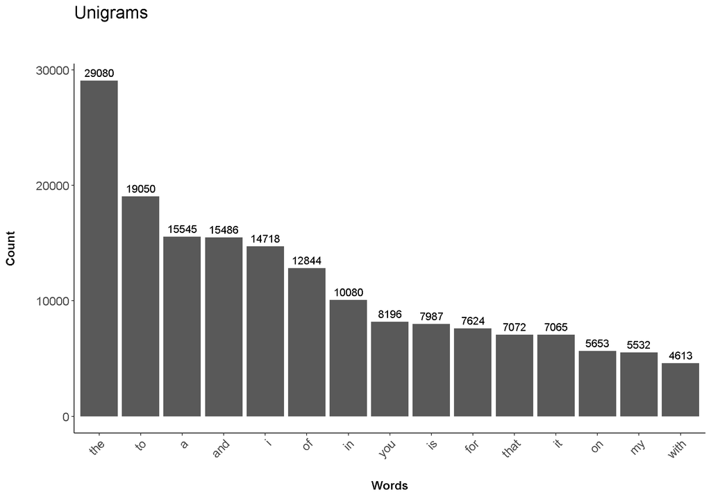

```r
UniGrams <- findNGrams(corpusDf, 1)
saveRDS(UniGrams, file = "Unigram.RDS")
```

Fig. 3. Unigram plot Appendix 3.

## Bigram data

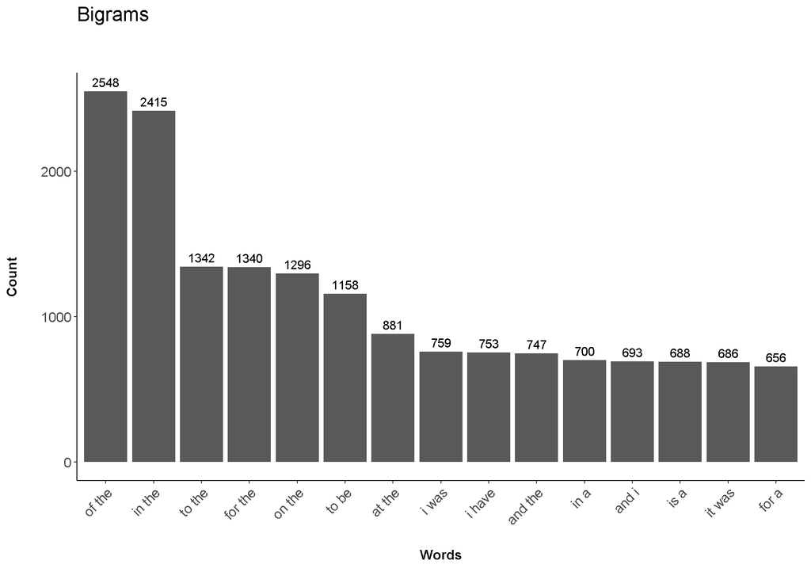

```r
BiGrams <- findNGrams(corpusDf, 2)
bigrams_sep <- separate(BiGrams, ngram, c("word1", "word2"), sep = " ")
saveRDS(bigrams_sep, file = "Bigram.RDS")
```

Fig. 4. Bigram plot Appendix 4.

## Trigram data

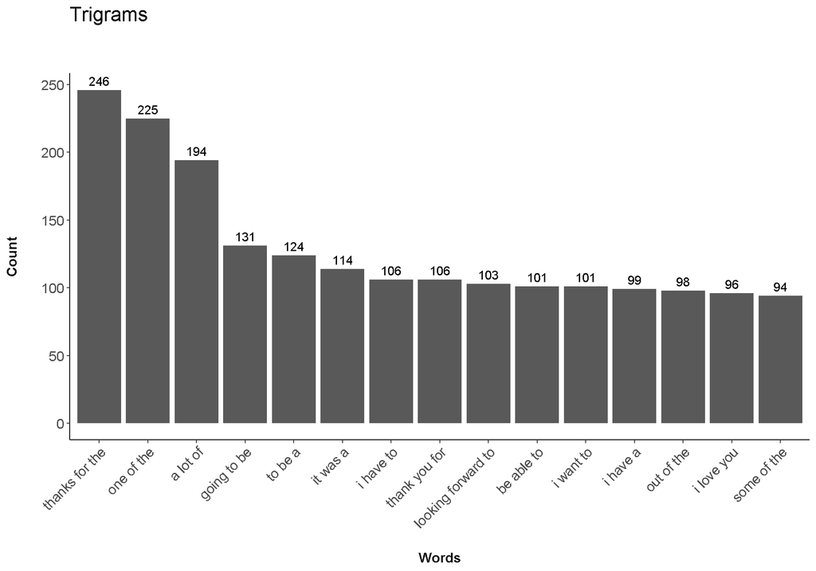

```r
TriGrams <- findNGrams(corpusDf, 3)
trigrams_sep <- separate(TriGrams, ngram, c("word1", "word2", "word3"), sep = " ")
saveRDS(trigrams_sep, file = "Trigram.RDS")
```

Fig. 5. Trigram plot Appendix 5.

# Built n-grams without English stop words

## Unigram data

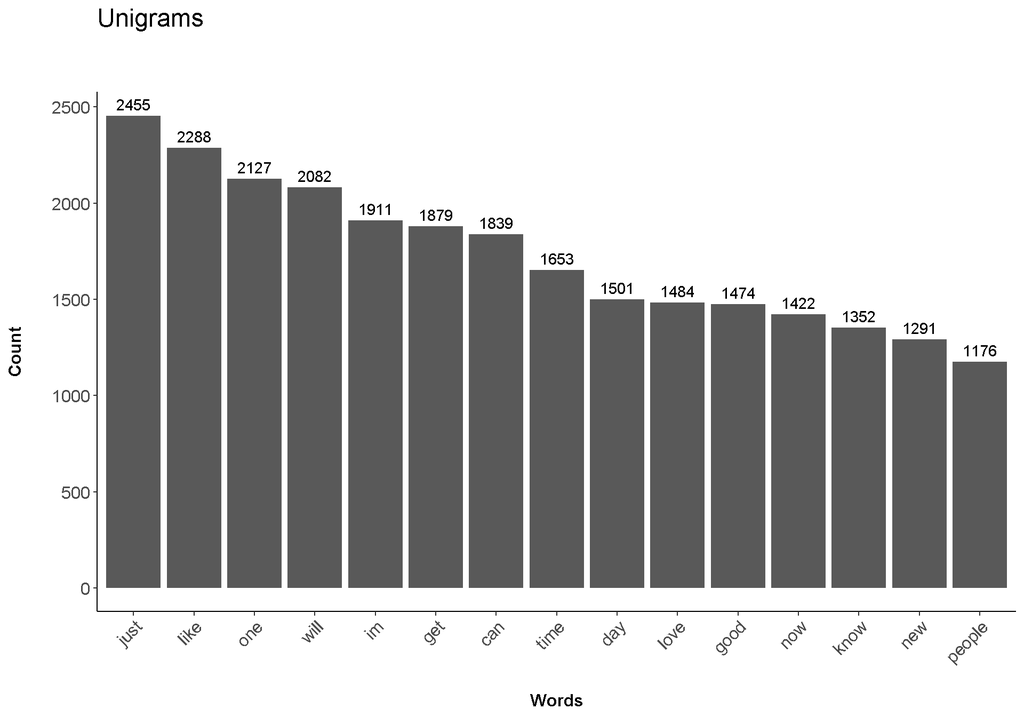

```r
UniGrams2 <- findNGrams(corpusDf2, 1)
saveRDS(UniGrams2, file = "Unigram1.RDS")
```

Fig. 6. Unigram plot Appendix 6.

## Bigram data

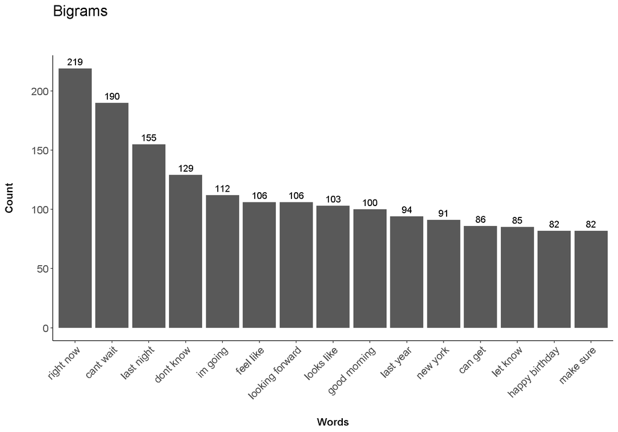

```r
BiGrams2 <- findNGrams(corpusDf2, 2)
bigrams_sep2 <- separate(BiGrams2, ngram, c("word1", "word2"), sep = " ")
saveRDS(bigrams_sep2, file = "Bigram1.RDS")
```

Fig. 7. Bigram plot Appendix 7.

## Trigram data

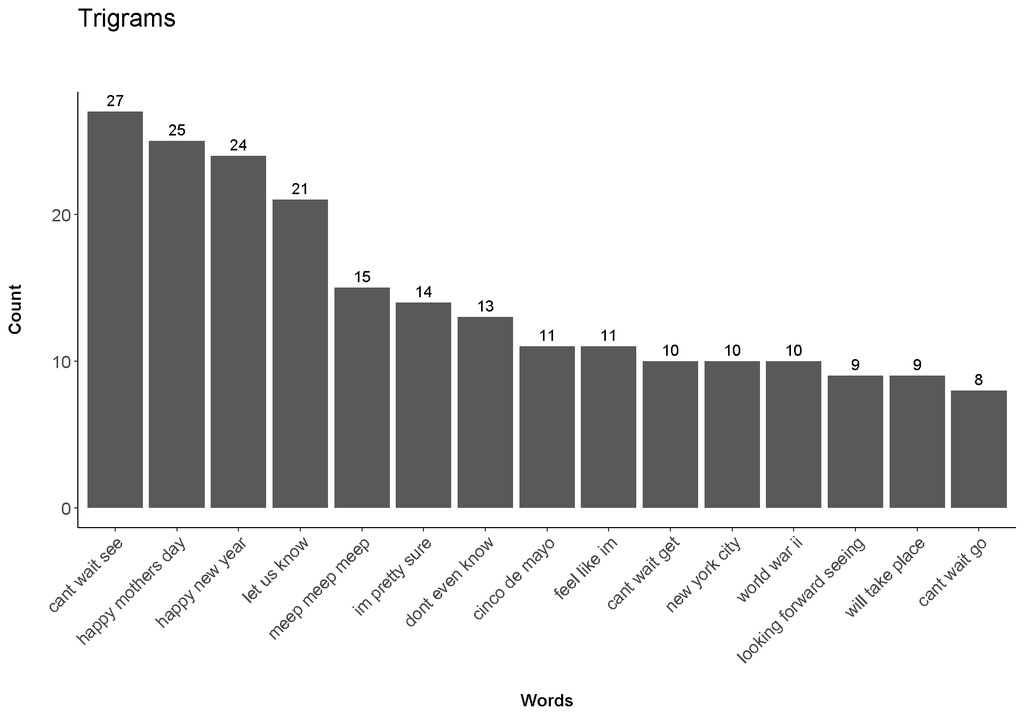

```r
TriGrams2 <- findNGrams(corpusDf2, 3)
trigrams_sep2 <- separate(TriGrams2, ngram, c("word1", "word2", "word3"), sep = " ")
saveRDS(trigrams_sep2, file = "Trigram1.RDS")
```

Fig. 8. Trigram plot Appendix 8.

# Appendix

Appendix 1

```r
ggplot(sum_data, aes(x = factor(File), y = Lines))+
        geom_bar(stat = "identity") +
        geom_text(aes(label = Lines), vjust = -0.5)+
        xlab("Text source") + ylab("Total of lines") +
        theme(axis.text.x = element_text(angle = 45, hjust = 1))+
        theme(plot.title = element_text(size = 25, face = "bold"))+
        theme(plot.title = element_text(margin = margin(0, 0, 20, 0)))+
        theme(axis.text.x = element_text(size = 12))+
        theme(axis.text.y = element_text(size = 12))+
        theme(axis.title.x = element_text(size = 12, face = "bold"))+
        theme(axis.title.x = element_text(margin = margin(20, 0, 0, 0)))+
        theme(axis.title.y = element_text(size = 12, face = "bold"))+
        theme(axis.title.y = element_text(margin = margin(0, 20, 0, 0)))+
        ggtitle(expression(textstyle(atop("Count of lines per source"))))+
        theme(panel.border = element_blank(), panel.grid.major = element_blank(),
              panel.grid.minor = element_blank(), axis.line = element_line(colour = "black"))+
        theme(panel.background = element_blank())
```

Appendix 2

```r
ggplot(sum_data, aes(x = factor(File), y = Total_Words))+
        geom_bar(stat = "identity") +
        geom_text(aes(label = round(Total_Words)), vjust = -0.5)+
        xlab("Text source") + ylab("Total of words") +
        theme(axis.text.x = element_text(angle = 45, hjust = 1))+
        theme(plot.title = element_text(size = 25, face = "bold"))+
        theme(plot.title = element_text(margin = margin(0, 0, 20, 0)))+
        theme(axis.text.x = element_text(size = 12))+
        theme(axis.text.y = element_text(size = 12))+
        theme(axis.title.x = element_text(size = 12, face = "bold"))+
        theme(axis.title.x = element_text(margin = margin(20, 0, 0, 0)))+
        theme(axis.title.y = element_text(size = 12, face = "bold"))+
        theme(axis.title.y = element_text(margin = margin(0, 20, 0, 0)))+
        ggtitle(expression(textstyle(atop("Count of words per source"))))+
        theme(panel.border = element_blank(), panel.grid.major = element_blank(),
              panel.grid.minor = element_blank(), axis.line = element_line(colour = "black"))+
        theme(panel.background = element_blank())
```

Appendix 3

```r
ggplot(head(UniGrams, 15), aes(x = reorder(ngram, -Freq), y = Freq)) +
        geom_bar(stat = "identity") +
        geom_text(aes(label = Freq), vjust = -0.5)+
        xlab("Words") + ylab("Count") +
        theme(axis.text.x = element_text(angle = 45, hjust = 1))+
        theme(plot.title = element_text(size = 25, face = "bold"))+
        theme(plot.title = element_text(margin = margin(0, 0, 20, 0)))+
        theme(axis.text.x = element_text(size = 12))+
        theme(axis.text.y = element_text(size = 12))+
        theme(axis.title.x = element_text(size = 12, face = "bold"))+
        theme(axis.title.x = element_text(margin = margin(20, 0, 0, 0)))+
        theme(axis.title.y = element_text(size = 12, face = "bold"))+
        theme(axis.title.y = element_text(margin = margin(0, 20, 0, 0)))+
        ggtitle(expression(textstyle(atop("Unigrams"))))+
        theme(panel.border = element_blank(), panel.grid.major = element_blank(),
              panel.grid.minor = element_blank(), axis.line = element_line(colour = "black"))+
        theme(panel.background = element_blank())
```

Appendix 4

```r
ggplot(head(BiGram, 15), aes(x = reorder(ngram, -Freq), y = Freq)) +
        geom_bar(stat = "identity") +
        geom_text(aes(label = Freq), vjust = -0.5)+
        xlab("Words") + ylab("Count") +
        theme(axis.text.x = element_text(angle = 45, hjust = 1))+
        theme(plot.title = element_text(size = 25, face = "bold"))+
        theme(plot.title = element_text(margin = margin(0, 0, 20, 0)))+
        theme(axis.text.x = element_text(size = 12))+
        theme(axis.text.y = element_text(size = 12))+
        theme(axis.title.x = element_text(size = 12, face = "bold"))+
        theme(axis.title.x = element_text(margin = margin(20, 0, 0, 0)))+
        theme(axis.title.y = element_text(size = 12, face = "bold"))+
        theme(axis.title.y = element_text(margin = margin(0, 20, 0, 0)))+
        ggtitle(expression(textstyle(atop("Bigrams"))))+
        theme(panel.border = element_blank(), panel.grid.major = element_blank(),
              panel.grid.minor = element_blank(), axis.line = element_line(colour = "black"))+
     theme(panel.background = element_blank())
```

Appendix 5

```r
ggplot(head(TriGram, 15), aes(x = reorder(ngram, -Freq), y = Freq)) +
        geom_bar(stat = "identity") +
        geom_text(aes(label = Freq), vjust = -0.5)+
        xlab("Words") + ylab("Count") +
        theme(axis.text.x = element_text(angle = 45, hjust = 1))+
        theme(plot.title = element_text(size = 25, face = "bold"))+
        theme(plot.title = element_text(margin = margin(0, 0, 20, 0)))+
        theme(axis.text.x = element_text(size = 12))+
        theme(axis.text.y = element_text(size = 12))+
        theme(axis.title.x = element_text(size = 12, face = "bold"))+
        theme(axis.title.x = element_text(margin = margin(20, 0, 0, 0)))+
        theme(axis.title.y = element_text(size = 12, face = "bold"))+
        theme(axis.title.y = element_text(margin = margin(0, 20, 0, 0)))+
        ggtitle(expression(textstyle(atop("Trigrams"))))+
        theme(panel.border = element_blank(), panel.grid.major = element_blank(),
              panel.grid.minor = element_blank(), axis.line = element_line(colour = "black"))+
     theme(panel.background = element_blank())
```

Appendix 6

```r
ggplot(head(UniGrams2, 15), aes(x = reorder(ngram, -Freq), y = Freq)) +
        geom_bar(stat = "identity") +
        geom_text(aes(label = Freq), vjust = -0.5)+
        xlab("Words") + ylab("Count") +
        theme(axis.text.x = element_text(angle = 45, hjust = 1))+
        theme(plot.title = element_text(size = 25, face = "bold"))+
        theme(plot.title = element_text(margin = margin(0, 0, 20, 0)))+
        theme(axis.text.x = element_text(size = 12))+
        theme(axis.text.y = element_text(size = 12))+
        theme(axis.title.x = element_text(size = 12, face = "bold"))+
        theme(axis.title.x = element_text(margin = margin(20, 0, 0, 0)))+
        theme(axis.title.y = element_text(size = 12, face = "bold"))+
        theme(axis.title.y = element_text(margin = margin(0, 20, 0, 0)))+
        ggtitle(expression(textstyle(atop("Unigrams"))))+
        theme(panel.border = element_blank(), panel.grid.major = element_blank(),
              panel.grid.minor = element_blank(), axis.line = element_line(colour = "black"))+
        theme(panel.background = element_blank())
```

Appendix 7

```r
ggplot(head(BiGram2, 15), aes(x = reorder(ngram, -Freq), y = Freq)) +
        geom_bar(stat = "identity") +
        geom_text(aes(label = Freq), vjust = -0.5)+
        xlab("Words") + ylab("Count") +
        theme(axis.text.x = element_text(angle = 45, hjust = 1))+
        theme(plot.title = element_text(size = 25, face = "bold"))+
        theme(plot.title = element_text(margin = margin(0, 0, 20, 0)))+
        theme(axis.text.x = element_text(size = 12))+
        theme(axis.text.y = element_text(size = 12))+
        theme(axis.title.x = element_text(size = 12, face = "bold"))+
        theme(axis.title.x = element_text(margin = margin(20, 0, 0, 0)))+
        theme(axis.title.y = element_text(size = 12, face = "bold"))+
        theme(axis.title.y = element_text(margin = margin(0, 20, 0, 0)))+
        ggtitle(expression(textstyle(atop("Bigrams"))))+
        theme(panel.border = element_blank(), panel.grid.major = element_blank(),
              panel.grid.minor = element_blank(), axis.line = element_line(colour = "black"))+
     theme(panel.background = element_blank())
```

Appendix 8

```r
ggplot(head(TriGram2, 15), aes(x = reorder(ngram, -Freq), y = Freq)) +
        geom_bar(stat = "identity") +
        geom_text(aes(label = Freq), vjust = -0.5)+
        xlab("Words") + ylab("Count") +
        theme(axis.text.x = element_text(angle = 45, hjust = 1))+
        theme(plot.title = element_text(size = 25, face = "bold"))+
        theme(plot.title = element_text(margin = margin(0, 0, 20, 0)))+
        theme(axis.text.x = element_text(size = 12))+
        theme(axis.text.y = element_text(size = 12))+
        theme(axis.title.x = element_text(size = 12, face = "bold"))+
        theme(axis.title.x = element_text(margin = margin(20, 0, 0, 0)))+
        theme(axis.title.y = element_text(size = 12, face = "bold"))+
        theme(axis.title.y = element_text(margin = margin(0, 20, 0, 0)))+
        ggtitle(expression(textstyle(atop("Trigrams"))))+
        theme(panel.border = element_blank(), panel.grid.major = element_blank(),
              panel.grid.minor = element_blank(), axis.line = element_line(colour = "black"))+
     theme(panel.background = element_blank())
```